# CSSS 563 - HW1

Courtney Allen

4/10/2022

## Question 1

Suppose the instantaneous mortality rate for a population is a constant that does not depend on age, equal to 0.02 per year.

### Q1.A

**Find analytically and plot the probability density function of age at death for this population.**

Probability density function is:

$$f(x) = \lambda e ^{-\lambda x}$$
$$\lambda = 0.02$$
$$f(x) = 0.02 e ^{-0.02 x}$$

The probability distribution of age at death is exponential:

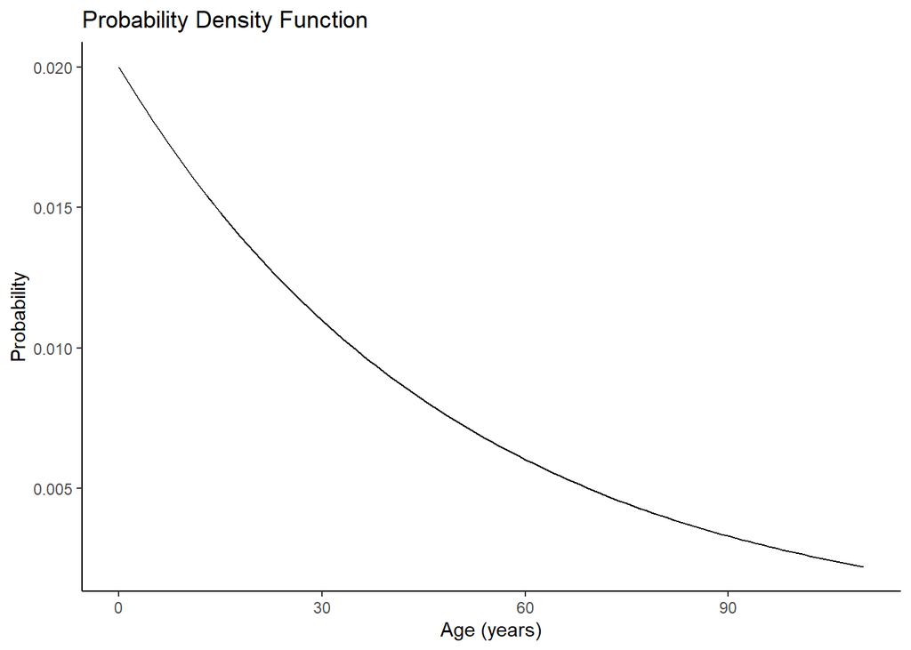

```r
lambda <- 0.02
beg_age <- 0
end_age <- 110
population_ages <- (tibble(age = seq(beg_age,end_age, 1)))


pdf = function(x) lambda*exp(-lambda*x)
pdf_plot =
  population_ages %>%
  mutate(PDF = pdf(age)) %>%
  ggplot(aes(x=age, y=PDF)) +
  geom_line() +
  theme_classic() +
  labs(
    title = "Probability Density Function",
    x = "Age (years)",
    y = "Probability"
    )

pdf_plot
```

### Q1.B

**Find the probability that a member of this population is still alive at age 70.**

The probability that a member of the population is still alive is represented by the Survival Function:

$$S(x) = Pr[X>x] = 1-F(x) = e ^{-\lambda x}$$
$$S(x) = e ^{-0.02*70}$$

```r
survival = function(x) exp(-lambda*x)

sx_70 <- survival(70)
```

The probablity of a member of the population surviving to age 70 is **0.25**.

### Q1.C

**Find the probability that a member of this population dies before age 6.**

The probability that a member of the population dies by a certain age is represented by the Cumulative Distribution Function:

$$f(x) = 1- e ^{-\lambda x}$$
$$f(x) = 1- e ^{-0.02 * 6}$$

```r
cdf = function(x) 1 - exp(-lambda*x)

qx_6 <- cdf(6)
```

### Q1.D

**Find the life expectancy at birth for a member of this population.**

Life expectancy can be found by integrating the survival function from 0 to infinity.

$$e_0 = E(X) = \int_{0}^{\infty} S(u)du$$

```r
e0 <- 1/0.02
```

The life expectancy at birth is **50**.

### Q1.E

**Find the life expectancy at age 50 for a member of this population.**

Life expectancy at age 50 is:

$$e_0 = E(X) = \int_{50}^{\infty} \frac{S(u)du}{S(50)}$$

```r
survival_function <- function(x) {
  exp(-lambda*x)
}
e50_temp <- integrate(survival_function, lower = 50, upper = Inf)
e50 <- e50_temp$value/survival_function(50)
```

The life expectancy at age 50 is **50**.

### Q1.F

**Find the median age at death for this population**

```r
population_ages <- (tibble(age = seq(1,110, 1)))

med_death <- (ln(2))/lambda
```

The median age at death is 34.66.

## Question 2

**Suppose the instantaneous mortality rate at age x for a cohort is$\mu$(x) = (0.0168x2 - 0.668x + 8)/1000**

**Denote by X the age at death of a person randomly chosen from this cohort (a random variable).**

### Q2.A

**Plot the instantaneous mortality rate for this cohort against age.**

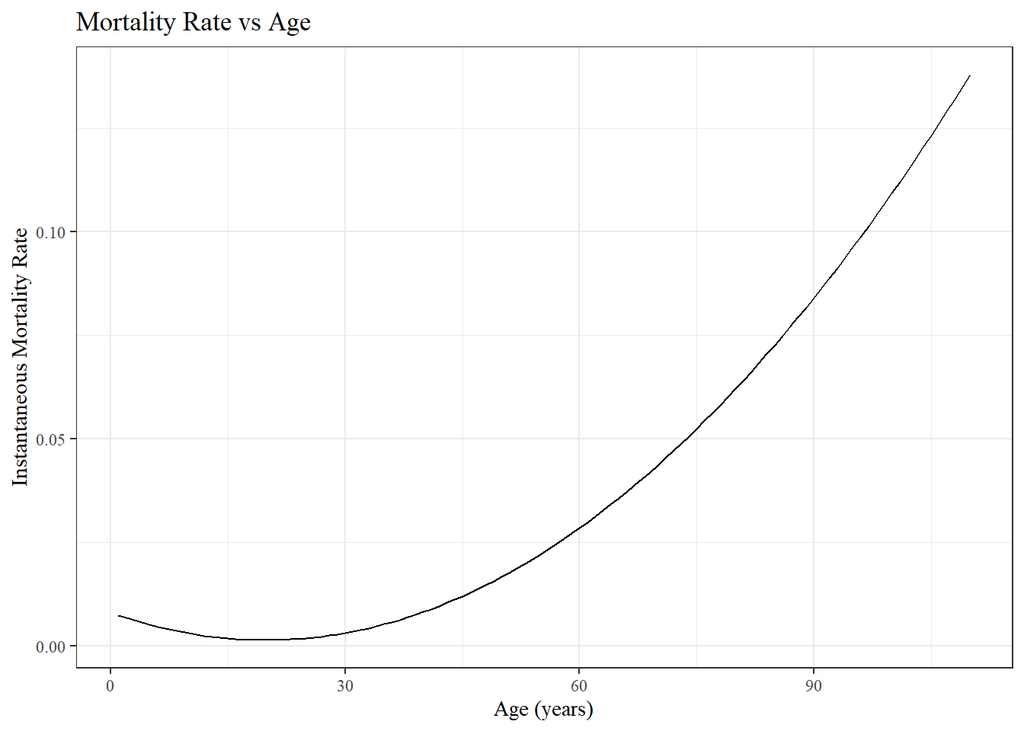

```r
hazard_fun = function(x) (0.0168*x^2 - 0.668*x + 8)/1000
imr_plot <- population_ages %>%
  mutate(mortality = hazard_fun(age)) %>%
  ggplot(aes(x = age, y = mortality)) +
  geom_line() +
  theme_bw() +
  theme(text = element_text(family = "serif")) +
  labs(
    title = "Mortality Rate vs Age",
    x = "Age (years)",
    y = "Instantaneous Mortality Rate"
  )
imr_plot
```

### Q2.B

**Find analytically and plot the cumulative hazard function of this distribution, (x).**

The cumulative hazard function is $\Lambda(x) = \int_{0}^{x} \mu(u)du$.

$$\begin{aligned} \Lambda(x) &= \int_{0}^{x} \mu(u) du \\
&= \int_{0}^{x} \left[(0.0168x^2 − 0.668x + 8)/1000 \right]dx \\
&= \int_{0}^{x} \dfrac{21x^2-835x+10000}{1250000}dx\\
\end{aligned}$$

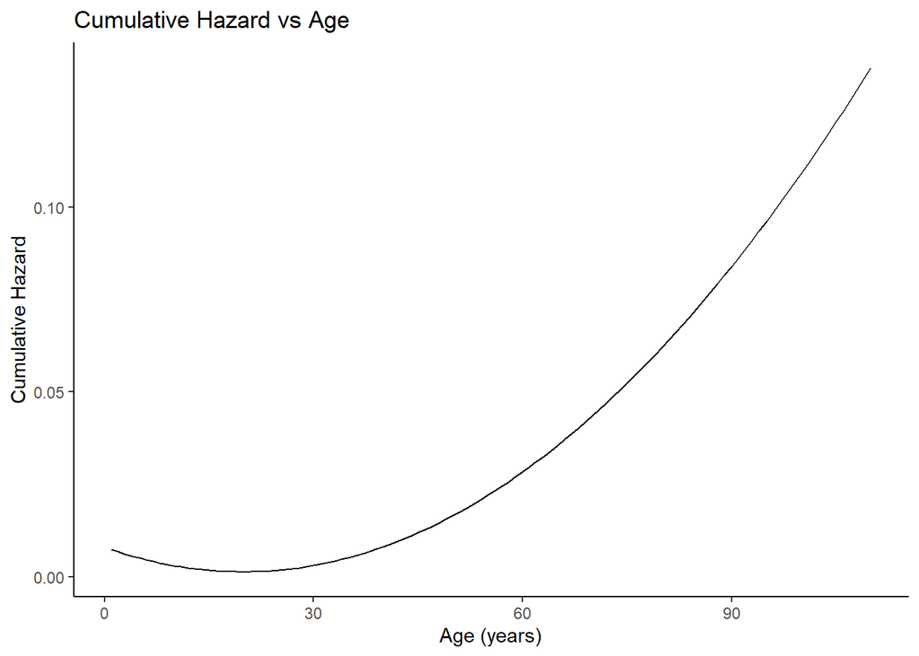

```r
cum_hazard_fun <- function(x) (-835*x + 21*x^2 + 10000)/1250000

chf_plot <- ggplot(population_ages, aes(x = age, y = cum_hazard_fun(age))) +
  geom_line() +
  theme_classic() +
  labs(
    title = "Cumulative Hazard vs Age",
    x = "Age (years)",
    y = "Cumulative Hazard"
  )

chf_plot
```

### Q2.C

**Find analytically and plot the survival function, S(x).**

The survival function is:

$$S(x) = exp^{-1*cumulativehazard}$$

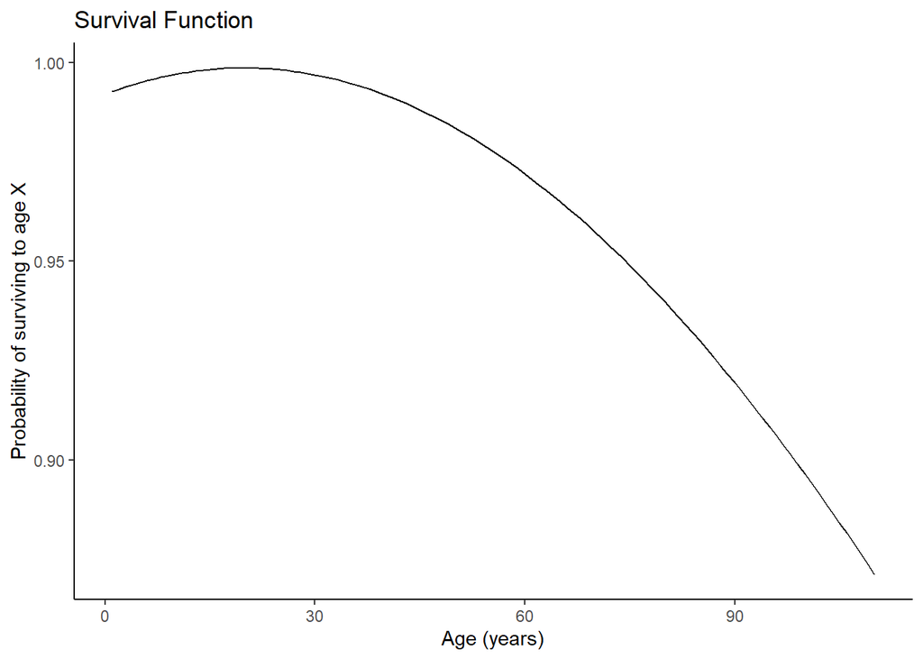

```r
survival_fun <- function(x) exp(-1 * cum_hazard_fun(x))
survival_fun <- function(x) exp(-1 * ((0.0168*x^2 - 0.668*x + 8)/1000))
surv_plot =
  population_ages %>%
  mutate(survive = survival_fun(age)) %>%
  ggplot(aes(x=age, y=survive)) +
  geom_line() +
  theme_classic() +
  labs(
    title = "Survival Function",
    x = "Age (years)",
    y = "Probability of surviving to age X"
    )

surv_plot
```

### Q2.D

**Find and plot the probability density function of X, f(x).**

[figure not shown]

```r
pdf_fun <- function(x) survival_fun(x) * hazard_fun(x)
pdfun_plot <-
  population_ages %>%
  mutate(pdf = pdf_fun(age)) %>%
  ggplot(aes(x = age, y = pdf)) +
  geom_line() +
  theme_classic() +
  labs(
    title = "Probability density vs Age",
    x = "Age (years)",
    y = "Probability density")

pdf_plot
```

### Q2.E

**Find the life expectancy at birth of a member of this cohort.**

Life expectancy is:

$$e_0 = E(X) = \int_{0}^{\infty} S(u)du$$

```r
q2_e0 <- integrate(survival_fun, lower = 0, upper = Inf)
```

The life expectancy at birth is **235.73**.

### Q2.F

**Find the life expectancy at age 10 of a member of this cohort.**

Life expectancy at age 10 is:

$$e_{10} = E(X) = \int_{10}^{\infty} \frac{S(u)du}{S(10)}$$

```r
e10_temp <- integrate(survival_function, lower = 10, upper = Inf)
e10 <- e10_temp$value/survival_function(10)
```

### Q2.G

**Find 45q15 for this cohort.**

$$_{n}q_{x} = \frac{_{n}d_{x}}{l_{x}} = \frac{l_{x}-l_{x+n}}{l_{x}} = \frac{S_{(x)}-S_{(x+n)}}{S_{(x)}}$$

```r
nqx <- function(x, n) (survival_fun(x) - survival_fun(x + n)) / survival_fun(x)
q45_15 <- round(nqx(15, 45), 3)
```

The probability of dying between ages 15 and 60 is **0.03**

## Question 3

**From the UN’s 2019 World Population Prospects extract and show:**

```r
library(wpp2019)
library(wppExplorer)
```

### Q3.A

**estimates of the male population of Peru in each of the age groups 70-74, 75-79, 80-84, 85-89, 90-94, 95+ in 2015 and 2020**

```r
# download estimates of males
data("popM")

# filter for Peru, ages 70+
df_pe <- popM %>%
  filter(country_code == 604,
         age == c("70-74", "75-79", "80-84", "85-89", "90-94", "95-99", "100+")) %>%
    select("age", "2015", "2020")

# make a table
df_pe %>%
  filter(age!="100+") %>%
  kable() %>%
  kable_paper("hover", full_width = F)
```

| age | 2015 | 2020 |
| --- | --- | --- |
| 70-74 | 275.296 | 352.748 |
| 75-79 | 202.698 | 243.752 |
| 80-84 | 125.197 | 161.173 |
| 85-89 | 52.703 | 71.136 |
| 90-94 | 12.832 | 21.842 |
| 95-99 | 2.181 | 3.646 |

### Q3.B

**estimates of the number of deaths in each of these age groups during the period 2015-2020.**

Deaths can be estimated by:

$$_{n}d_{x} = l_{x} - l_{x+n}$$

```r
# create deaths by measuring lx - lx+n
df_pe <- df_pe %>%
  mutate(deaths = `2015` - lead(`2020`))

# make a table
df_pe %>%
  filter(age!="100+") %>%
  rename(`deaths (thousands)` = deaths) %>%
  kable() %>%
  kable_paper("hover", full_width = F)
```

| age | 2015 | 2020 | deaths (thousands) |
| --- | --- | --- | --- |
| 70-74 | 275.296 | 352.748 | 31.544 |
| 75-79 | 202.698 | 243.752 | 41.525 |
| 80-84 | 125.197 | 161.173 | 54.061 |
| 85-89 | 52.703 | 71.136 | 30.861 |
| 90-94 | 12.832 | 21.842 | 9.186 |
| 95-99 | 2.181 | 3.646 | 1.786 |

## QUESTION 4

### Q4.A

**Use these estimates to:** **estimate $_5M_x$ for ages x = 70; 75; 80; 85; 90; 95 for males in Peru for the period 2015-2020**

The age-specific mortality rate is:

$$_{n}M_{x} = \frac{_{n}d_{x}}{_{n}L_{x}}$$

```r
df_pe <- df_pe %>%
  mutate(nLx = (5*(`2015`+`2020`)/2),
         nMx = deaths/nLx)


df_pe %>%
  filter(age!="100+") %>%
  kable() %>%
  kable_paper("hover", full_width = F)
```

| age | 2015 | 2020 | deaths | nLx | nMx |
| --- | --- | --- | --- | --- | --- |
| 70-74 | 275.296 | 352.748 | 31.544 | 1570.1100 | 0.0200903 |
| 75-79 | 202.698 | 243.752 | 41.525 | 1116.1250 | 0.0372046 |
| 80-84 | 125.197 | 161.173 | 54.061 | 715.9250 | 0.0755121 |
| 85-89 | 52.703 | 71.136 | 30.861 | 309.5975 | 0.0996810 |
| 90-94 | 12.832 | 21.842 | 9.186 | 86.6850 | 0.1059699 |
| 95-99 | 2.181 | 3.646 | 1.786 | 14.5675 | 0.1226017 |

### Q4.B

**estimate 5qx for ages x = 70; 75; 80; 85; 90; 95 for males in Peru for the period 2015-2020, using each of the two approximations discussed in class.**

Solution 1:

$$_nq_x \approx 1-exp(-n_nM_x)$$

```r
# estimate first method of approximation for nqx
df_pe <- df_pe %>%
  mutate(nqx_1 = 1-exp(-5*nMx))
```

Solution 2:

$$_nq_x \approx \frac{n_nM_x}{1+n {_nM_x}/2}$$

```r
# estimate second method of approximation for nqx
df_pe <- df_pe %>%
  mutate(nqx_2 = (5*nMx)/(1+5*nMx/2))

df_pe %>%
  filter(age!="100+") %>%
  select(age, `2015`, `2020`, deaths, nMx, nqx_1, nqx_2) %>%
  kable() %>%
  kable_paper("hover", full_width = F)
```

| age | 2015 | 2020 | deaths | nMx | nqx_1 | nqx_2 |
| --- | --- | --- | --- | --- | --- | --- |
| 70-74 | 275.296 | 352.748 | 31.544 | 0.0200903 | 0.0955711 | 0.0956476 |
| 75-79 | 202.698 | 243.752 | 41.525 | 0.0372046 | 0.1697456 | 0.1701931 |
| 80-84 | 125.197 | 161.173 | 54.061 | 0.0755121 | 0.3144683 | 0.3176033 |
| 85-89 | 52.703 | 71.136 | 30.861 | 0.0996810 | 0.3925013 | 0.3989787 |
| 90-94 | 12.832 | 21.842 | 9.186 | 0.1059699 | 0.4113064 | 0.4188782 |
| 95-99 | 2.181 | 3.646 | 1.786 | 0.1226017 | 0.4582813 | 0.4691974 |

### Q4.C

**estimate $_5m_x$ for the same ages**

The age-specific mortality rate is:

$$_{n}m_{x} = \frac{_{n}d_{x}}{_{n}L_{x}} = \frac{_{n}d_{x}}{nl_{x} - \frac{1}{2}n_nd_x}$$

```r
df_pe <- df_pe %>%
  mutate(nLx_approx = (5*`2015`-(1/2)*5*deaths),
         nmx = deaths/nLx_approx)


df_pe %>%
  filter(age!="100+") %>%
  select(age, `2015`, `2020`, deaths, nLx_approx, nmx) %>%
  kable() %>%
  kable_paper("hover", full_width = F)
```

| age | 2015 | 2020 | deaths | nLx_approx | nmx |
| --- | --- | --- | --- | --- | --- |
| 70-74 | 275.296 | 352.748 | 31.544 | 1297.6200 | 0.0243091 |
| 75-79 | 202.698 | 243.752 | 41.525 | 909.6775 | 0.0456480 |
| 80-84 | 125.197 | 161.173 | 54.061 | 490.8325 | 0.1101414 |
| 85-89 | 52.703 | 71.136 | 30.861 | 186.3625 | 0.1655966 |
| 90-94 | 12.832 | 21.842 | 9.186 | 41.1950 | 0.2229882 |
| 95-99 | 2.181 | 3.646 | 1.786 | 6.4400 | 0.2773292 |

### Q4.D

**Compare the estimates from the two approximations. Which of the two approximations do you think is better? Why?**

```r
df_pe %>%
  filter(age!="100+") %>%
  select(age, `2015`, `2020`, deaths, nMx, nqx_1, nqx_2) %>%
  kable() %>%
  kable_paper("hover", full_width = F)
```

| age | 2015 | 2020 | deaths | nMx | nqx_1 | nqx_2 |
| --- | --- | --- | --- | --- | --- | --- |
| 70-74 | 275.296 | 352.748 | 31.544 | 0.0200903 | 0.0955711 | 0.0956476 |
| 75-79 | 202.698 | 243.752 | 41.525 | 0.0372046 | 0.1697456 | 0.1701931 |
| 80-84 | 125.197 | 161.173 | 54.061 | 0.0755121 | 0.3144683 | 0.3176033 |
| 85-89 | 52.703 | 71.136 | 30.861 | 0.0996810 | 0.3925013 | 0.3989787 |
| 90-94 | 12.832 | 21.842 | 9.186 | 0.1059699 | 0.4113064 | 0.4188782 |
| 95-99 | 2.181 | 3.646 | 1.786 | 0.1226017 | 0.4582813 | 0.4691974 |

The table above shows the two approximations for $_nq_x$, the probability of dying in an age group of those aged x to x+n. The estimates are very close, though as $_nM_x$ gets larger, there is a larger discrepancy between the approximations.

I believe the first approximation ($_nq_x \approx 1-exp(-n_nM_x)$) is better because the equation is based on the assumption that the mortality rate is constant over time within the age interval. I believe this is intuitive and *mostly* true for these age groups, except not for the oldest age groups.

### Q4.E

**Compare the estimates of $_5M_x$ and $_5m_x$ with one other, and comment on any dfferences.**

```r
df_pe %>%
  filter(age!="100+") %>%
  select(age, `2015`, `2020`, deaths, nLx, nLx_approx, nMx, nmx) %>%
  kable() %>%
  kable_paper("hover", full_width = F)
```

| age | 2015 | 2020 | deaths | nLx | nLx_approx | nMx | nmx |
| --- | --- | --- | --- | --- | --- | --- | --- |
| 70-74 | 275.296 | 352.748 | 31.544 | 1570.1100 | 1297.6200 | 0.0200903 | 0.0243091 |
| 75-79 | 202.698 | 243.752 | 41.525 | 1116.1250 | 909.6775 | 0.0372046 | 0.0456480 |
| 80-84 | 125.197 | 161.173 | 54.061 | 715.9250 | 490.8325 | 0.0755121 | 0.1101414 |
| 85-89 | 52.703 | 71.136 | 30.861 | 309.5975 | 186.3625 | 0.0996810 | 0.1655966 |
| 90-94 | 12.832 | 21.842 | 9.186 | 86.6850 | 41.1950 | 0.1059699 | 0.2229882 |
| 95-99 | 2.181 | 3.646 | 1.786 | 14.5675 | 6.4400 | 0.1226017 | 0.2773292 |

For each age group $_nM_x$ is smaller than $_nm_x$. $_nM_x$ uses the person years calculated in $_nL_x$ column, while the $_nm_x$ utilizes the `nLx_approx` column (which assumes linear function of person years over the interval). $_nM_x$ may be underestimating mortality by using person-years estimates from population counts, while $_nm_x$ actually accounts for deaths in the cohort when estimating person-years. As can be seen, $_nL_x$ estimates more person-years lived than `nLx_approx`. Older folks who die in these age groups may not live half of the interval as is assumed, so $_nm_x$ may be more of an accurate estimate of the mortality rate.

## QUESTION 5

**For each of the two approximations:**

### Q5.A

**Derive a life table ($l_x$ only) for a cohort of 10,000 males aged 70.**

To construct a cohort life table *ONLY* using nqx values we’ll rely on the following equations:

Deaths
$$_nd_x = _nq_x*_nlx$$

Probability of surviving
$$_np_x = 1-_nq_x$$

Person-years lived above age x
$$_nT_x = \sum_{a=x}^{inf}{_nL_a}$$

Life expectancy
$$e^0_x = \frac{T_x}{l_x}$$

```r
lt_1 <- df_pe %>%
  select(age, nqx_1) %>%
  mutate(
    n = 5,
    npx = 1-nqx_1,
    nqx = case_when(
      age=="100+" ~ 1,
      TRUE ~ nqx_1    )) %>%
  select(-nqx_1)


# rest of ages
x <- seq(70,100,5)
radix <- 10000
lx <- radix
npx <- lt_1$npx

#fill out rest of table
for (a in x[-length(x)]) {
  l <- lx[which(x == a)] * npx[which(x == a)]
  lx <- c(lx, l)
}
lt_1 <- lt_1 %>%
  mutate(
    x = x,
    lx = lx,
    ndx = lx*nqx,
    Lx = n*lx - n*ndx/2,
    Tx = rev(Lx) %>% coalesce(0) %>% cumsum() %>% rev(),
    ex = Tx / lx
  )
```

```r
lt_2 <- df_pe %>%
  select(age, nqx_2) %>%
  mutate(
    n = 5,
    npx = 1-nqx_2,
    nqx = case_when(
      age=="100+" ~ 1,
      TRUE ~ nqx_2    )) %>%
  select(-nqx_2)


# rest of ages
x <- seq(70,100,5)
radix <- 10000
lx <- radix
npx <- lt_2$npx

#fill out rest of table
for (a in x[-length(x)]) {
  l <- lx[which(x == a)] * npx[which(x == a)]
  lx <- c(lx, l)
}
lt_2 <- lt_2 %>%
  mutate(
    x = x,
    lx = lx,
    ndx = lx*nqx,
    Lx = n*lx - n*ndx/2,
    Tx = rev(Lx) %>% coalesce(0) %>% cumsum() %>% rev(),
    ex = Tx / lx
  )
```

Below are two life tables, each life table uses a different approximation technique for nqx.

```r
lt_1 %>% select(-x,-n) %>%
  kable %>%
  kable_paper("hover", full_width = F)
```

| age | npx | nqx | lx | ndx | Lx | Tx | ex |
| --- | --- | --- | --- | --- | --- | --- | --- |
| 70-74 | 0.9044289 | 0.0955711 | 10000.0000 | 955.7108 | 47610.723 | 163332.684 | 16.333268 |
| 75-79 | 0.8302544 | 0.1697456 | 9044.2892 | 1535.2279 | 41383.376 | 115721.961 | 12.795031 |
| 80-84 | 0.6855317 | 0.3144683 | 7509.0613 | 2361.3615 | 31641.903 | 74338.585 | 9.899851 |
| 85-89 | 0.6074987 | 0.3925013 | 5147.6997 | 2020.4787 | 20687.302 | 42696.683 | 8.294323 |
| 90-94 | 0.5886936 | 0.4113064 | 3127.2211 | 1286.2461 | 12420.490 | 22009.381 | 7.038000 |
| 95-99 | 0.5417187 | 0.4582813 | 1840.9750 | 843.6844 | 7095.664 | 9588.890 | 5.208594 |
| 100+ | NA | 1.0000000 | 997.2906 | 997.2906 | 2493.226 | 2493.226 | 2.500000 |

```r
lt_2 %>% select(-x,-n) %>%
  kable %>%
  kable_paper("hover", full_width = F)
```

| age | npx | nqx | lx | ndx | Lx | Tx | ex |
| --- | --- | --- | --- | --- | --- | --- | --- |
| 70-74 | 0.9043524 | 0.0956476 | 10000.0000 | 956.4759 | 47608.810 | 162423.193 | 16.242319 |
| 75-79 | 0.8298069 | 0.1701931 | 9043.5241 | 1539.1458 | 41369.756 | 114814.382 | 12.695757 |
| 80-84 | 0.6823967 | 0.3176033 | 7504.3783 | 2383.4151 | 31563.354 | 73444.626 | 9.786903 |
| 85-89 | 0.6010213 | 0.3989787 | 5120.9632 | 2043.1551 | 20496.928 | 41881.272 | 8.178398 |
| 90-94 | 0.5811218 | 0.4188782 | 3077.8081 | 1289.2269 | 12165.973 | 21384.344 | 6.947913 |
| 95-99 | 0.5308026 | 0.4691974 | 1788.5812 | 839.1977 | 6844.912 | 9218.371 | 5.154013 |
| 100+ | NA | 1.0000000 | 949.3835 | 949.3835 | 2373.459 | 2373.459 | 2.500000 |

### Q5.B

**Estimate the life expectancy at age 70 from each of the two approximations, and compare the two estimates. Comment on any differences, and why they arise.**

```r
cbind(age = lt_1$x, nqx_1=lt_1$nqx, nqx_2=lt_2$nqx, ex_1= lt_1$ex, ex_2=lt_2$ex) %>%
  kable(., digits=2)  %>%
  kable_paper("hover", full_width = F)
```

| age | nqx_1 | nqx_2 | ex_1 | ex_2 |
| --- | --- | --- | --- | --- |
| 70 | 0.10 | 0.10 | 16.33 | 16.24 |
| 75 | 0.17 | 0.17 | 12.80 | 12.70 |
| 80 | 0.31 | 0.32 | 9.90 | 9.79 |
| 85 | 0.39 | 0.40 | 8.29 | 8.18 |
| 90 | 0.41 | 0.42 | 7.04 | 6.95 |
| 95 | 0.46 | 0.47 | 5.21 | 5.15 |
| 100 | 1.00 | 1.00 | 2.50 | 2.50 |

Above, you can compare the life expectancies that use different $_nq_x$ approximations.

The first approximation technique estimates slightly higher life expectancies. These are very slight and most life expectancies are within a few decimal points. The first approximation technique estimates slightly lower probabilities of dying which is why the life expectancies are slightly longer for this approach.

# Appendix

```r
lambda <- 0.02
beg_age <- 0
end_age <- 110
population_ages <- (tibble(age = seq(beg_age,end_age, 1)))


pdf = function(x) lambda*exp(-lambda*x)
pdf_plot =
  population_ages %>%
  mutate(PDF = pdf(age)) %>%
  ggplot(aes(x=age, y=PDF)) +
  geom_line() +
  theme_classic() +
  labs(
    title = "Probability Density Function",
    x = "Age (years)",
    y = "Probability"
    )

pdf_plot


survival = function(x) exp(-lambda*x)

sx_70 <- survival(70)

cdf = function(x) 1 - exp(-lambda*x)

qx_6 <- cdf(6)




e0 <- 1/0.02


survival_function <- function(x) {
  exp(-lambda*x)
}
e50_temp <- integrate(survival_function, lower = 50, upper = Inf)
e50 <- e50_temp$value/survival_function(50)


population_ages <- (tibble(age = seq(1,110, 1)))

med_death <- (ln(2))/lambda
hazard_fun = function(x) (0.0168*x^2 - 0.668*x + 8)/1000
imr_plot <- population_ages %>%
  mutate(mortality = hazard_fun(age)) %>%
  ggplot(aes(x = age, y = mortality)) +
  geom_line() +
  theme_bw() +
  theme(text = element_text(family = "serif")) +
  labs(
    title = "Mortality Rate vs Age",
    x = "Age (years)",
    y = "Instantaneous Mortality Rate"
  )
imr_plot


cum_hazard_fun <- function(x) (-835*x + 21*x^2 + 10000)/1250000

chf_plot <- ggplot(population_ages, aes(x = age, y = cum_hazard_fun(age))) +
  geom_line() +
  theme_classic() +
  labs(
    title = "Cumulative Hazard vs Age",
    x = "Age (years)",
    y = "Cumulative Hazard"
  )

chf_plot




survival_fun <- function(x) exp(-1 * cum_hazard_fun(x))
survival_fun <- function(x) exp(-1 * ((0.0168*x^2 - 0.668*x + 8)/1000))
surv_plot =
  population_ages %>%
  mutate(survive = survival_fun(age)) %>%
  ggplot(aes(x=age, y=survive)) +
  geom_line() +
  theme_classic() +
  labs(
    title = "Survival Function",
    x = "Age (years)",
    y = "Probability of surviving to age X"
    )

surv_plot


pdf_fun <- function(x) survival_fun(x) * hazard_fun(x)
pdfun_plot <-
  population_ages %>%
  mutate(pdf = pdf_fun(age)) %>%
  ggplot(aes(x = age, y = pdf)) +
  geom_line() +
  theme_classic() +
  labs(
    title = "Probability density vs Age",
    x = "Age (years)",
    y = "Probability density")

pdf_plot



q2_e0 <- integrate(survival_fun, lower = 0, upper = Inf)

e10_temp <- integrate(survival_function, lower = 10, upper = Inf)
e10 <- e10_temp$value/survival_function(10)


nqx <- function(x, n) (survival_fun(x) - survival_fun(x + n)) / survival_fun(x)
q45_15 <- round(nqx(15, 45), 3)

library(wpp2019)
library(wppExplorer)


# download estimates of males
data("popM")

# filter for Peru, ages 70+
df_pe <- popM %>%
  filter(country_code == 604,
         age == c("70-74", "75-79", "80-84", "85-89", "90-94", "95-99", "100+")) %>%
    select("age", "2015", "2020")

# make a table
df_pe %>%
  filter(age!="100+") %>%
  kable() %>%
  kable_paper("hover", full_width = F)


# create deaths by measuring lx - lx+n
df_pe <- df_pe %>%
  mutate(deaths = `2015` - lead(`2020`))

# make a table
df_pe %>%
  filter(age!="100+") %>%
  rename(`deaths (thousands)` = deaths) %>%
  kable() %>%
  kable_paper("hover", full_width = F)


df_pe <- df_pe %>%
  mutate(nLx = (5*(`2015`+`2020`)/2),
         nMx = deaths/nLx)


df_pe %>%
  filter(age!="100+") %>%
  kable() %>%
  kable_paper("hover", full_width = F)


# estimate first method of approximation for nqx
df_pe <- df_pe %>%
  mutate(nqx_1 = 1-exp(-5*nMx))



# estimate second method of approximation for nqx
df_pe <- df_pe %>%
  mutate(nqx_2 = (5*nMx)/(1+5*nMx/2))

df_pe %>%
  filter(age!="100+") %>%
  select(age, `2015`, `2020`, deaths, nMx, nqx_1, nqx_2) %>%
  kable() %>%
  kable_paper("hover", full_width = F)

df_pe <- df_pe %>%
  mutate(nLx_approx = (5*`2015`-(1/2)*5*deaths),
         nmx = deaths/nLx_approx)


df_pe %>%
  filter(age!="100+") %>%
  select(age, `2015`, `2020`, deaths, nLx_approx, nmx) %>%
  kable() %>%
  kable_paper("hover", full_width = F)


df_pe %>%
  filter(age!="100+") %>%
  select(age, `2015`, `2020`, deaths, nMx, nqx_1, nqx_2) %>%
  kable() %>%
  kable_paper("hover", full_width = F)

df_pe %>%
  filter(age!="100+") %>%
  select(age, `2015`, `2020`, deaths, nLx, nLx_approx, nMx, nmx) %>%
  kable() %>%
  kable_paper("hover", full_width = F)

lt_1 <- df_pe %>%
  select(age, nqx_1) %>%
  mutate(
    n = 5,
    npx = 1-nqx_1,
    nqx = case_when(
      age=="100+" ~ 1,
      TRUE ~ nqx_1    )) %>%
  select(-nqx_1)


# rest of ages
x <- seq(70,100,5)
radix <- 10000
lx <- radix
npx <- lt_1$npx

#fill out rest of table
for (a in x[-length(x)]) {
  l <- lx[which(x == a)] * npx[which(x == a)]
  lx <- c(lx, l)
}
lt_1 <- lt_1 %>%
  mutate(
    x = x,
    lx = lx,
    ndx = lx*nqx,
    Lx = n*lx - n*ndx/2,
    Tx = rev(Lx) %>% coalesce(0) %>% cumsum() %>% rev(),
    ex = Tx / lx
  )


lt_2 <- df_pe %>%
  select(age, nqx_2) %>%
  mutate(
    n = 5,
    npx = 1-nqx_2,
    nqx = case_when(
      age=="100+" ~ 1,
      TRUE ~ nqx_2    )) %>%
  select(-nqx_2)


# rest of ages
x <- seq(70,100,5)
radix <- 10000
lx <- radix
npx <- lt_2$npx

#fill out rest of table
for (a in x[-length(x)]) {
  l <- lx[which(x == a)] * npx[which(x == a)]
  lx <- c(lx, l)
}
lt_2 <- lt_2 %>%
  mutate(
    x = x,
    lx = lx,
    ndx = lx*nqx,
    Lx = n*lx - n*ndx/2,
    Tx = rev(Lx) %>% coalesce(0) %>% cumsum() %>% rev(),
    ex = Tx / lx
  )



lt_1 %>% select(-x,-n) %>%
  kable %>%
  kable_paper("hover", full_width = F)

lt_2 %>% select(-x,-n) %>%
  kable %>%
  kable_paper("hover", full_width = F)



cbind(age = lt_1$x, nqx_1=lt_1$nqx, nqx_2=lt_2$nqx, ex_1= lt_1$ex, ex_2=lt_2$ex) %>%
  kable(., digits=2)  %>%
  kable_paper("hover", full_width = F)
```